# Bank Marketing Dataset Ethical Analysis

### `age` vs Target Variable

- **Absolute Counts:** Most clients—both those who subscribed ("yes") and those who did not ("no")—fall within the 30–50 age range.
- **Subscription Rate (Proportion):** The relative share of "yes" responses is highest among younger clients (around 20–30) and older clients (over 60). The middle-aged group (30–50) shows a lower overall subscription rate.

### `marital` vs Target Variable

- **Absolute Counts:** Married clients make up the largest share of both positive ("yes") and negative ("no") outcomes.
- **Subscription Rate (Proportion):** Single clients show a higher likelihood of subscription compared to married or divorced clients.

### `job` vs Target Variable

- **Absolute Counts:** The majority of clients belong to the "blue-collar," "management," or "technician" categories.
- **Subscription Rate (Proportion):** Subscription likelihood differs widely across occupations:
  - **Higher Rates:** "Student" and "retired" groups have the highest proportion of "yes" responses.
  - **Lower Rates:** "Blue-collar" and "entrepreneur" groups show the lowest proportion of subscriptions.
  - This indicates a notable disparity tied to socio-economic status.

### `education` vs Target Variable

- **Absolute Counts:** Most clients have "secondary" or "tertiary" education.
- **Subscription Rate (Proportion):** The "tertiary" group shows a higher rate of subscriptions than the "secondary" and "primary" groups, while the "unknown" category also performs relatively well.

## Analysis of non-sensitive targets with target variable

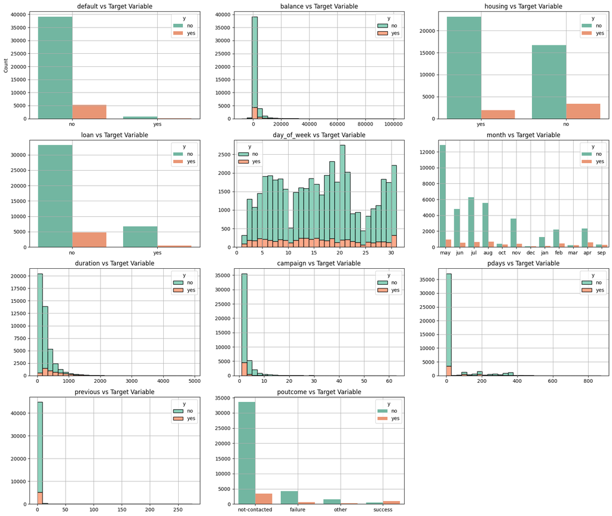

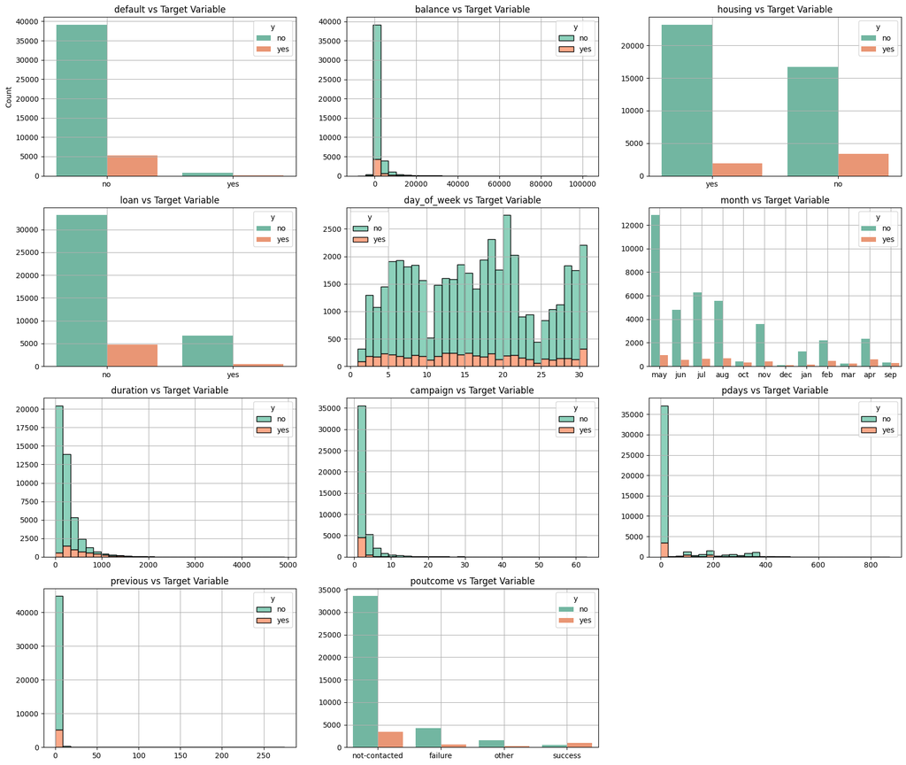

```python
plt.figure(figsize=(21, 18))
non_sensitive_attributes = cleaned_df.drop(
    columns=["y"] + sensitive_attributes
).columns.tolist()
for _attr in non_sensitive_attributes:
    plt.subplot(4, 3, non_sensitive_attributes.index(_attr) + 1)
    if cleaned_df[_attr].dtype == "object":
        sns.countplot(data=cleaned_df, x=_attr, hue="y", palette="Set2")
    else:
        sns.histplot(
            data=cleaned_df,
            x=_attr,
            hue="y",
            multiple="stack",
            bins=30,
            palette="Set2",
        )
    plt.title(f"{_attr} vs Target Variable")
    if _attr == "default":
        plt.ylabel("Count")
    else:
        plt.ylabel("")
    plt.xlabel("")
    plt.grid()
plt.gcf()
```